# Анализ повторных покупок: какие клиенты приносят больше всего прибыли (Когортный анализ и оценка LTV)

### Цель проекта

Проанализировать, какие клиенты возвращаются чаще и приносят больше денег. Найти точки роста для увелечения повторных продаж.

### Рекомендации

1. Проанализировать апрельских клиентов, чтобы понять, откуда они, почему покупают много, но редко возвращаются. Проверить маркетинговые каналы.
2. Понять, в чем успех работы с мартовскими клиентами и привлечь похожих.
3. Протестировать гипотезу с улучшением первого впечатления: приветственное письмо, чек-лист в коробке, скидка на вторую покупку или что-то другое. Запустить тест на одной категории товаров или на ограниченной выборке клиентов, чтобы оценить, возвращаются ли клиенты чаще или нет.
4. Взять на карандаш июньских клиентов: проверить, вернутся ли они через 1-2 месяца. Если да, то это новая "золотая жила", на которую стоит обратить повышенное внимание. Если нет - просто разовый всплеск.

```
В этой и последующих таблицах появляются значения NaN. Это значит, что группа клиентов по месяцу привлечения еще не достигла срока жизненного цикла,
указанного в столбце.
```

| Месяц привлечения | Старт (1-ый месяц) | Спустя 1 месяц | Спустя 2 месяца | Спустя 3 месяца | Спустя 4 месяца | Спустя 5 месяцев |
| --- | --- | --- | --- | --- | --- | --- |
| 2026-01 | 180.0 | 58.0 | 28.0 | 16.0 | 10.0 | 4.0 |
| 2026-02 | 210.0 | 72.0 | 43.0 | 27.0 | 19.0 | NaN |
| 2026-03 | 240.0 | 85.0 | 47.0 | 23.0 | NaN | NaN |
| 2026-04 | 260.0 | 83.0 | 50.0 | NaN | NaN | NaN |
| 2026-05 | 290.0 | 97.0 | NaN | NaN | NaN | NaN |
| 2026-06 | 320.0 | NaN | NaN | NaN | NaN | NaN |

```
Процент удержания клиентов
```

| Месяц привлечения | Старт (1-ый месяц) | Спустя 1 месяц | Спустя 2 месяца | Спустя 3 месяца | Спустя 4 месяца | Спустя 5 месяцев |
| --- | --- | --- | --- | --- | --- | --- |
| 2026-01 | 100.0 | 32.2 | 15.6 | 8.9 | 5.6 | 2.2 |
| 2026-02 | 100.0 | 34.3 | 20.5 | 12.9 | 9.0 | NaN |
| 2026-03 | 100.0 | 35.4 | 19.6 | 9.6 | NaN | NaN |
| 2026-04 | 100.0 | 31.9 | 19.2 | NaN | NaN | NaN |
| 2026-05 | 100.0 | 33.4 | NaN | NaN | NaN | NaN |
| 2026-06 | 100.0 | NaN | NaN | NaN | NaN | NaN |

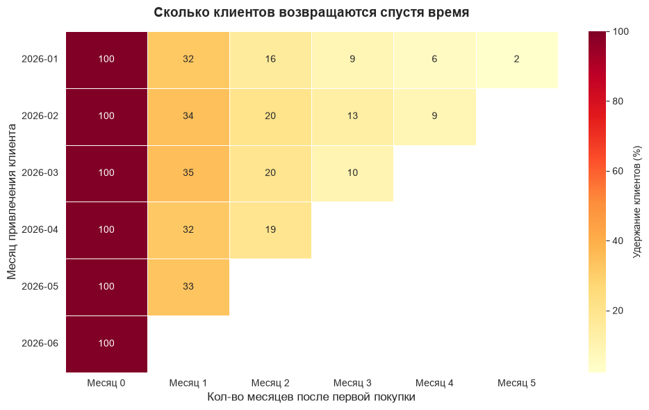

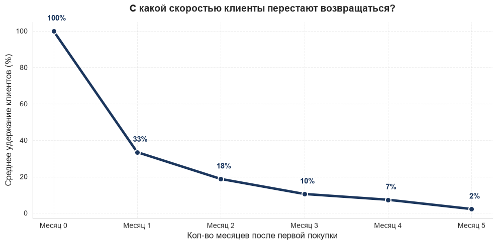

```
Суммарная выручка со всех клиентов спустя время (данные указаны в тыс. рублей)
```

| Месяц привлечения | Старт (1-ый месяц) | Спустя 1 месяц | Спустя 2 месяца | Спустя 3 месяца | Спустя 4 месяца | Спустя 5 месяцев |
| --- | --- | --- | --- | --- | --- | --- |
| 2026-01 | 650.7 | 838.8 | 952.1 | 1019.6 | 1038.9 | 1056.0 |
| 2026-02 | 717.3 | 999.7 | 1152.2 | 1274.4 | 1329.0 | NaN |
| 2026-03 | 888.4 | 1198.0 | 1386.8 | 1469.1 | NaN | NaN |
| 2026-04 | 1021.4 | 1323.2 | 1538.5 | NaN | NaN | NaN |
| 2026-05 | 942.7 | 1276.8 | NaN | NaN | NaN | NaN |
| 2026-06 | 1168.6 | NaN | NaN | NaN | NaN | NaN |

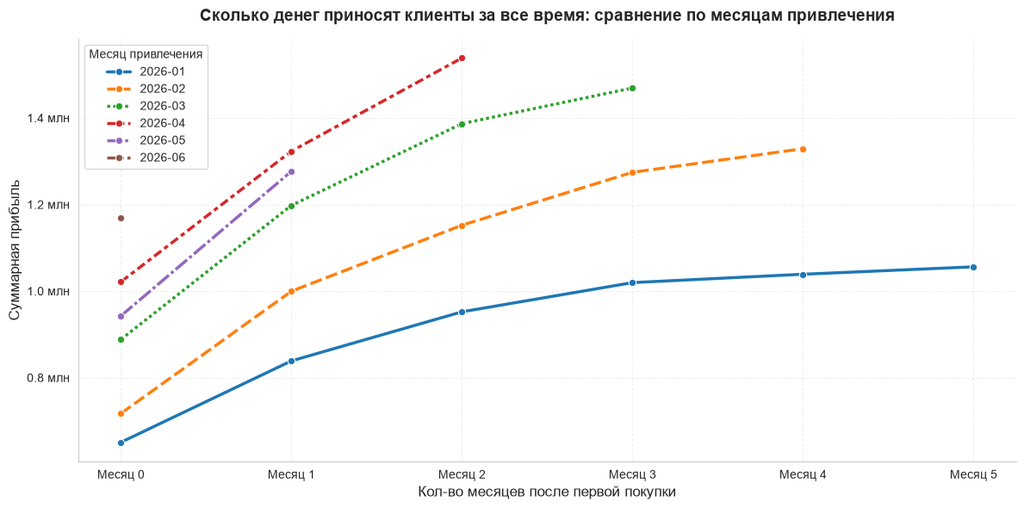

```
Рейтинг по удержанию после первого месяца:
```

| Месяц привлечения | Удержание после 1-го месяца (%) |
| --- | --- |
| 2026-03 | 35.4 |
| 2026-02 | 34.3 |
| 2026-05 | 33.4 |
| 2026-01 | 32.2 |
| 2026-04 | 31.9 |
| 2026-06 | NaN |

```
Рейтинг по суммарной прибыли после третьего месяца:
```

| Месяц привлечения | Суммарная прибыль после трех месяцев |
| --- | --- |
| 2026-03 | 1469106.0 |
| 2026-02 | 1274429.0 |
| 2026-01 | 1019556.0 |
| 2026-04 | NaN |
| 2026-05 | NaN |
| 2026-06 | NaN |